# 로지스틱 회귀분석을 통한 재실여부 예측

```
목표 : 로지스틱 회귀분석을 통해 재실여부를 예측하여, 모델의 accuracy값을 98% 이상 만들기
```

### 0. 데이터 불러오기 및 라이브러리 세팅

```r
library(lubridate)
library(MASS)
library(dplyr)
library(caret)
library(ggplot2)

train <- read.csv("https://github.com/otzslayer/KHURStudy/raw/master/2016%20Big%20Leader%204th/Data/occupancy_train.csv")
test <- read.csv("https://github.com/otzslayer/KHURStudy/raw/master/2016%20Big%20Leader%204th/Data/occupancy_test.csv")
```

### 1. 데이터 시각화를 통한 탐색

먼저, 데이터는 `Date(날짜)`, `Temperature(온도)`, `Humidity(습도)`, `HumidityRate(절대습도)`, `CO2(이산화탄소량)`, `Light(조도)`로 구성되어있다. 재실인원을 예측하는 회사데이터라는 점을 참고했을때, 출근일, 출근시간이 날짜에서 뽑아낼 수 있는 재실예측 수치라고 생각했다. 실제로 date에는 2015년 2월의 기록만 담겨있기 때문에 이용할 수 있는 요소는 `Day`와 `Time`요소였다. 일반적으로 주말엔 출근을 하지 않으니 요일별로 재실여부를 시각화 해보기로 했다.

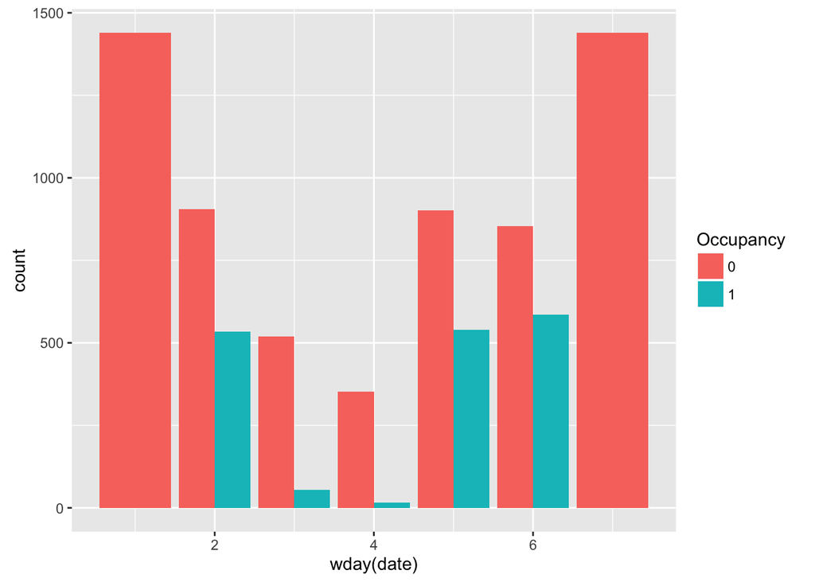

```r
train$date = as.POSIXct(train$date)
test$date = as.POSIXct(test$date)
train$Occupancy = as.factor(train$Occupancy)
test$Occupancy = as.factor(test$Occupancy)

ggplot(train, aes(x = wday(date), fill = Occupancy)) +
  geom_bar(stat="count", position=position_dodge())
```

위의 그래프를 통해 **1(일요일)과 7(토요일)**의 값에 재실인원이 없다는 것을 확인할 수 있었다. 주 5일 근무가 확실하게 지켜지고 있는 것 같다. 다음으로 시간요소를 활용하여 출근시간과 퇴근시간을 추측해보기로 했다.

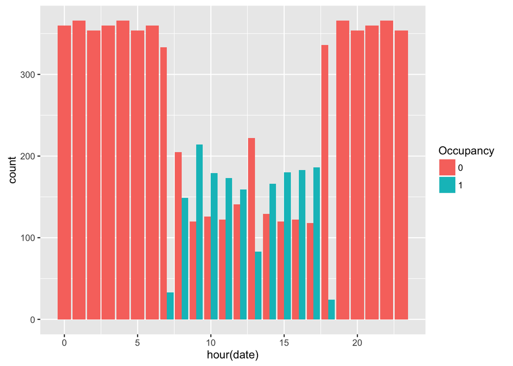

```r
ggplot(train, aes(x = hour(date), fill = Occupancy)) +
  geom_bar(stat="count", position=position_dodge())
```

### 2. 변수조정

```r
train_2 = train %>%
  mutate(weekday = ifelse(wday(date) > 1 & wday(date) < 7, 1, 0)) %>%
  mutate(worktime = ifelse(hour(date) >= 7 & hour(date) <= 17, 1, 0))

test_2 = test %>%
  mutate(weekday = ifelse(wday(date) > 1 & wday(date) < 7, 1, 0)) %>%
  mutate(worktime = ifelse(hour(date) >= 7 & hour(date) <= 17, 1, 0))
```

`weekday`변수엔 주중에 출근할 경우 1, 아니면 0으로 코딩하였고, `worktime`엔 업무시간일 경우 1, 아니면 0으로 코딩하였다.

### 3. 공선성 이슈

변수간의 상관관계가 높을 경우 모델의 성능이 떨어질 수 있으므로 변수간 공선성을 확인해보았다.

```r
train %>%
  select(-Occupancy, -date) %>%
  cor()
```

```
##               Temperature    Humidity      Light       CO2 HumidityRatio
## Temperature     1.0000000 -0.14175931 0.64994184 0.5598938     0.1517616
## Humidity       -0.1417593  1.00000000 0.03782794 0.4390228     0.9551981
## Light           0.6499418  0.03782794 1.00000000 0.6640221     0.2304202
## CO2             0.5598938  0.43902276 0.66402206 1.0000000     0.6265559
## HumidityRatio   0.1517616  0.95519808 0.23042022 0.6265559     1.0000000
```

그 결과 `Humidity`변수와 `HumidityRatio`변수의 높은 상관관계를 알 수 있었다. 이름부터가 비슷해서 의심스러웠는데 검색해보니 **상대습도**와 **절대습도**라고 한다. 이 중 어떤 변수가 더 설명력이 높은지 보기 위해 두 변수를 시각화 시켜보았다.

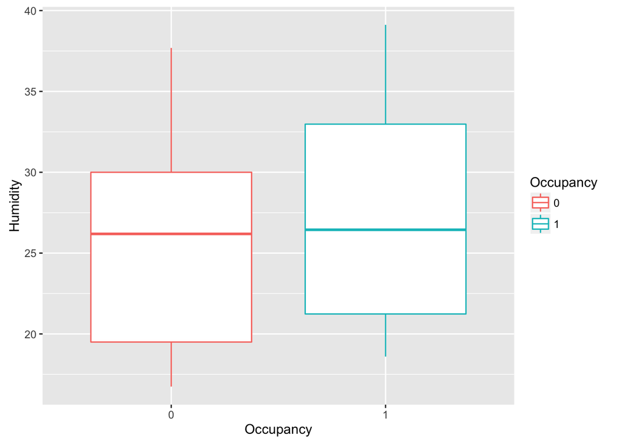

```r
ggplot(train, aes(x = Occupancy, y = Humidity, color = Occupancy)) +
  geom_boxplot()
```

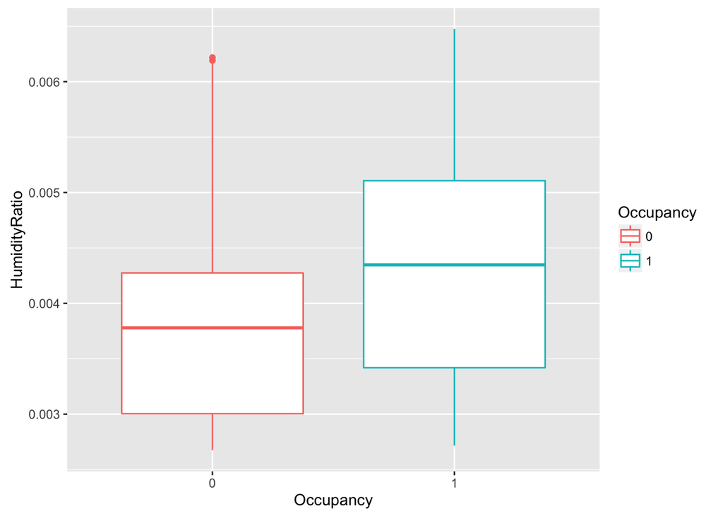

```r
ggplot(train, aes(x = Occupancy, y = HumidityRatio, color = Occupancy)) +
  geom_boxplot()
```

재실인 경우, 재실이 아닌 경우에 확실히 차이가나는 것은 `HumidityRatio(절대습도)`이므로 습도값을 버리고 절대습도 값으로 모델을 구성하기로 했다.

### 4. 모델 구성

```r
 model = glm(Occupancy ~ Temperature + Light + CO2 + HumidityRatio + weekday + worktime, data = train_2, family = "binomial")
 predict_occupancy = predict(model, test_2, type = "response")
 head(predict_occupancy)
```

```
##         1         2         3         4         5         6
## 0.9465525 0.9373695 0.9361424 0.9428329 0.9384922 0.9425370
```

```r
 binary_predict_occupancy = ifelse(predict_occupancy > 0.5, 1, 0)

 confusionMatrix(binary_predict_occupancy, test_2$Occupancy, positive = "1")
```

```
## Confusion Matrix and Statistics
##
##           Reference
## Prediction    0    1
##          0 7655   36
##          1   48 2013
##
##                Accuracy : 0.9914
##                  95% CI : (0.9893, 0.9931)
##     No Information Rate : 0.7899
##     P-Value [Acc > NIR] : <2e-16
##
##                   Kappa : 0.9741
##  Mcnemar's Test P-Value : 0.2301
##
##             Sensitivity : 0.9824
##             Specificity : 0.9938
##          Pos Pred Value : 0.9767
##          Neg Pred Value : 0.9953
##              Prevalence : 0.2101
##          Detection Rate : 0.2064
##    Detection Prevalence : 0.2113
##       Balanced Accuracy : 0.9881
##
##        'Positive' Class : 1
##
```

### 5. 성능 추가개선

좀 더 모델의 성능을 개선하고자 출근 시간 이후에 재실여부, 즉 야근으로 보이는 행동을 추가하여 모델을 개선하고자 하였다.

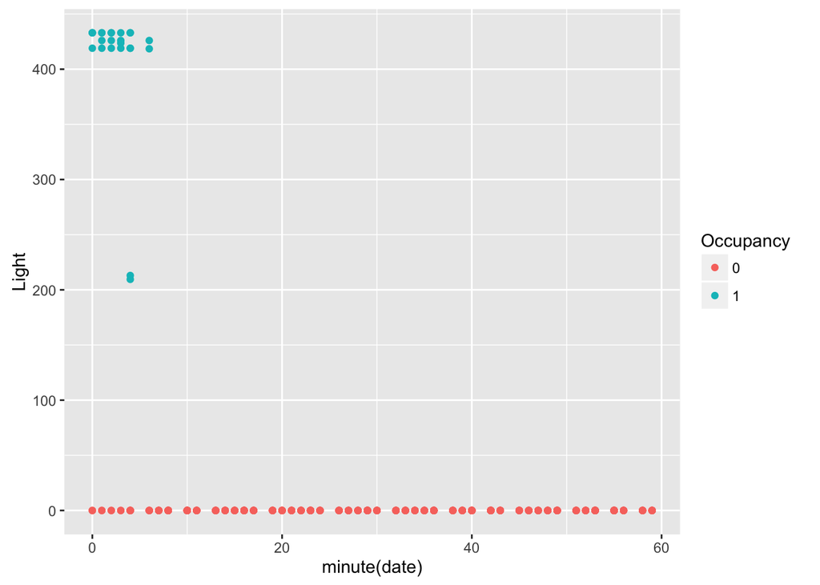

```r
overwork = train %>%
  filter(hour(date) == 18)

ggplot(overwork, aes(x = minute(date), y = Light,color = Occupancy)) +
  geom_point()
```

19시 이후에 야근하는 케이스는 이상치로 판단하고 18시 데이터만 국한하여 분 단위로 쪼개서 보기 위해 데이터를 시각화 한 결과, 재실중일 경우 `Light`의 값이 400이상으로 일반적으로 사무실에서 볼 수 있는 조도값을 확인할 수 있었다. 이를 통해 2가지를 확인해보고자 했다.

1. 18시부터 19시 사이에 조도값이 400이상일 경우 야근 or 업무를 마무리하는 사람이 있다.
2. 18시에 퇴근이어서 대부분 10분이내에 업무를 마무리하고 퇴근하는 것으로 보인다.

```r
train_3 = train_2 %>%
  mutate(nightwork = ifelse(hour(date) == 18 & Light > 400, 1, 0))

test_3 = test_2 %>%
  mutate(nightwork = ifelse(hour(date) == 18 & Light > 400, 1, 0))
model_2 = glm(Occupancy ~ Temperature + Light + CO2 + HumidityRatio + weekday + worktime + nightwork, data = train_3, family = "binomial")
predict_occupancy = predict(model_2, test_3, type = "response")
binary_predict_occupancy = ifelse(predict_occupancy > 0.5, 1, 0)

confusionMatrix(binary_predict_occupancy, test_3$Occupancy, positive = "1")
```

```
## Confusion Matrix and Statistics
##
##           Reference
## Prediction    0    1
##          0 7523  206
##          1  180 1843
##
##                Accuracy : 0.9604
##                  95% CI : (0.9564, 0.9642)
##     No Information Rate : 0.7899
##     P-Value [Acc > NIR] : <2e-16
##
##                   Kappa : 0.8802
##  Mcnemar's Test P-Value : 0.2032
##
##             Sensitivity : 0.8995
##             Specificity : 0.9766
##          Pos Pred Value : 0.9110
##          Neg Pred Value : 0.9733
##              Prevalence : 0.2101
##          Detection Rate : 0.1890
##    Detection Prevalence : 0.2074
##       Balanced Accuracy : 0.9380
##
##        'Positive' Class : 1
##
```

하지만 결과값은 **96.04%**로 현저하게 예측률이 떨어지는 것을 확인했다. 과적합이 발생한 것 같다. test데이터를 확인했을 때, 18시 데이터에서 조도가 400이상일 경우 하나의 케이스를 빼고 모두 재실중이었는데 왜 예측률이 떨어지는지 모르겠다.

### 6. 이상치 제거

두번째 모델을 버리고, 더 적합한 설명을 하기보다 아예 이상치를 제거하는 방법을 써보기로 했다.

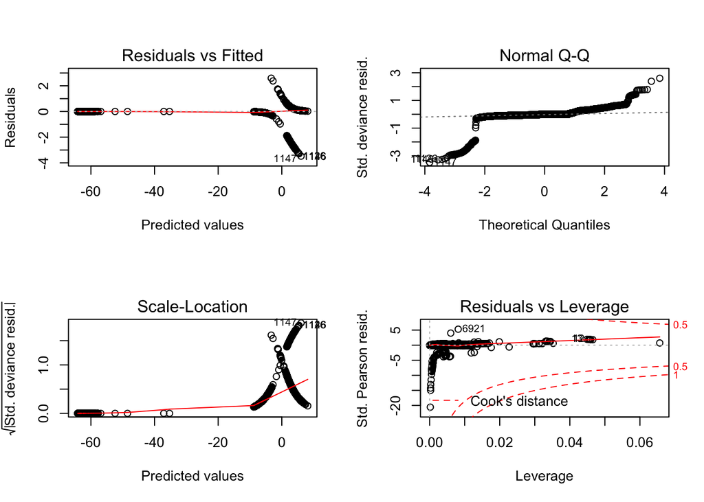

```r
par(mfrow = c(2,2))
plot(model)
```

4번째 그래프의 y축이 `residual`이 아니라 `pearson residual`이라 이상해서 첫 번째 그래프를 보니 `residual`값은 절대값 3이내에서 대부분 머무는 것을 확인할 수 있었다. 따라서 3으로 기준하기보다 **-20을 기록하는 값을 제거**하고, **leverage값이 0.05이상인 값을 제거**하여 이상치를 제거하였다.

```r
leverage = hatvalues(model)
leverage_point = which(leverage > 0.05)
stdlier = studres(model)
outliers = which(stdlier < -20)

train_5 = train_2[-leverage_point, ]
train_5 = train_5[-outliers, ]

model_4 = glm(Occupancy ~ Temperature + Light + CO2 + HumidityRatio + weekday + worktime, data = train_5, family = "binomial")
# 모델평가
predict_occupancy = predict(model_4, test_2, type = "response")
binary_predict_occupancy = ifelse(predict_occupancy > 0.5, 1, 0)

confusionMatrix(binary_predict_occupancy, test_2$Occupancy, positive = "1")
```

```
## Confusion Matrix and Statistics
##
##           Reference
## Prediction    0    1
##          0 7655   14
##          1   48 2035
##
##                Accuracy : 0.9936
##                  95% CI : (0.9919, 0.9951)
##     No Information Rate : 0.7899
##     P-Value [Acc > NIR] : < 2.2e-16
##
##                   Kappa : 0.981
##  Mcnemar's Test P-Value : 2.777e-05
##
##             Sensitivity : 0.9932
##             Specificity : 0.9938
##          Pos Pred Value : 0.9770
##          Neg Pred Value : 0.9982
##              Prevalence : 0.2101
##          Detection Rate : 0.2087
##    Detection Prevalence : 0.2136
##       Balanced Accuracy : 0.9935
##
##        'Positive' Class : 1
##
```